# BIMM 143 Class 15

Anika Bhattacharjya (A15459876)

# Bioconductor and DESeq2 setup

```r
#install.packages("BiocManager")
#BiocManager::install()
#BiocManager::install("DESeq2")
```

```r
library(BiocManager)
library(DESeq2)
```

# Import countData and colData

```r
counts <- read.csv("airway_scaledcounts.csv", row.names=1)
metadata <-  read.csv("airway_metadata.csv")
```

```r
head(counts)
```

```
##                 SRR1039508 SRR1039509 SRR1039512 SRR1039513 SRR1039516
## ENSG00000000003        723        486        904        445       1170
## ENSG00000000005          0          0          0          0          0
## ENSG00000000419        467        523        616        371        582
## ENSG00000000457        347        258        364        237        318
## ENSG00000000460         96         81         73         66        118
## ENSG00000000938          0          0          1          0          2
##                 SRR1039517 SRR1039520 SRR1039521
## ENSG00000000003       1097        806        604
## ENSG00000000005          0          0          0
## ENSG00000000419        781        417        509
## ENSG00000000457        447        330        324
## ENSG00000000460         94        102         74
## ENSG00000000938          0          0          0
```

```r
head(metadata)
```

```
##           id     dex celltype     geo_id
## 1 SRR1039508 control   N61311 GSM1275862
## 2 SRR1039509 treated   N61311 GSM1275863
## 3 SRR1039512 control  N052611 GSM1275866
## 4 SRR1039513 treated  N052611 GSM1275867
## 5 SRR1039516 control  N080611 GSM1275870
## 6 SRR1039517 treated  N080611 GSM1275871
```

> Q1. How many genes are in this dataset?

```r
nrow(counts)
```

```
## [1] 38694
```

38694 genes

> Q2. How many ‘control’ cell lines do we have?

```r
sum(metadata$dex == "control")
```

```
## [1] 4
```

4 control cell lines

# Toy differential gene expression

Need to extract all the ‘control’ columns before taking the row-wise mean to get the average count values for all genes in these 4 experiments:

```r
control <- metadata[metadata[,"dex"]=="control",]
control.counts <- counts[ ,control$id]
control.mean <- rowMeans(control.counts)
head(control.mean)
```

```
## ENSG00000000003 ENSG00000000005 ENSG00000000419 ENSG00000000457 ENSG00000000460
##          900.75            0.00          520.50          339.75           97.25
## ENSG00000000938
##            0.75
```

> Q3. How would you make the above code in either approach more robust?

Get rid of the ‘/4’ and just take rowMeans because the number of data points will change over time and may not always be 4. In class we used rowMeans already so I never used the “control.mean <- rowSums(control.counts)/4” code.

> Q4. Follow the same procedure for the treated samples (i.e. calculate the mean per gene across drug treated samples and assign to a labeled vector called treated.mean)

Finding ‘treated’ mean:

```r
treated <- metadata[metadata[,"dex"]=="treated",]
treated.counts <-counts[ ,treated$id]
treated.mean <-rowMeans(treated.counts)
head(treated.mean)
```

```
## ENSG00000000003 ENSG00000000005 ENSG00000000419 ENSG00000000457 ENSG00000000460
##          658.00            0.00          546.00          316.50           78.75
## ENSG00000000938
##            0.00
```

Combine meancount data for bookkeeping purposes

```r
meancounts <- data.frame(control.mean, treated.mean)

# Sum of mean for all counts
colSums(meancounts)
```

```
## control.mean treated.mean
##     23005324     22196524
```

> Q5 (a). Create a scatter plot showing the mean of the treated samples against the mean of the control samples.

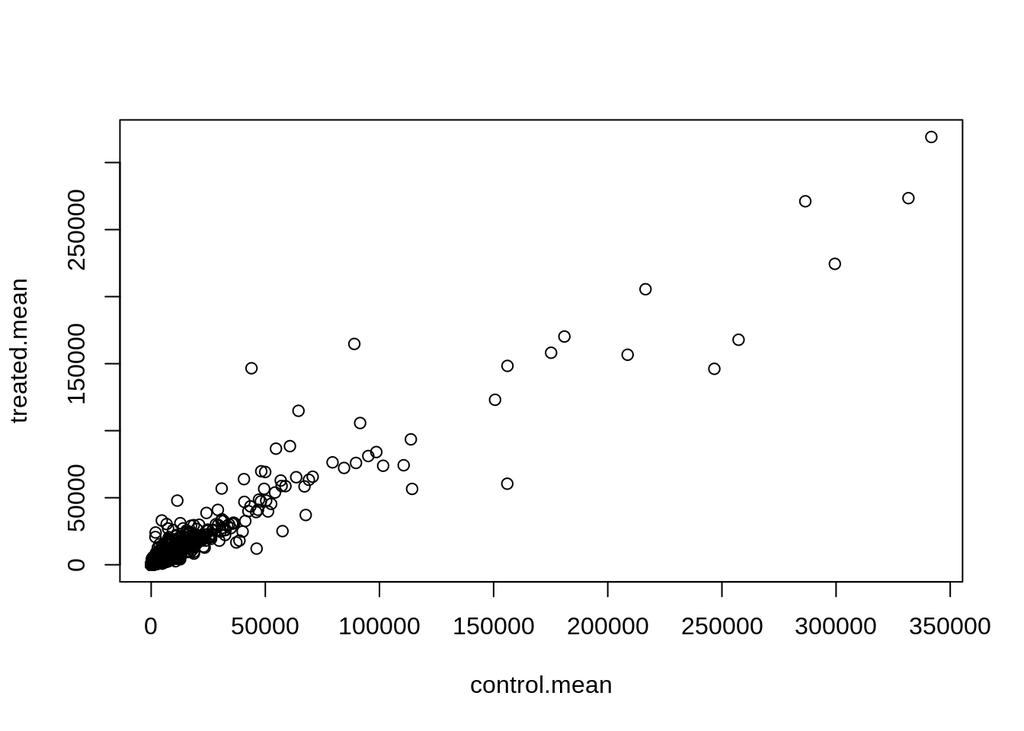

```r
plot(meancounts)
```

> Q5 (b).You could also use the ggplot2 package to make this figure producing the plot below. What geom_?() function would you use for this plot?

You would use geom_point.

> Q6. Try plotting both axes on a log scale. What is the argument to plot() that allows you to do this?

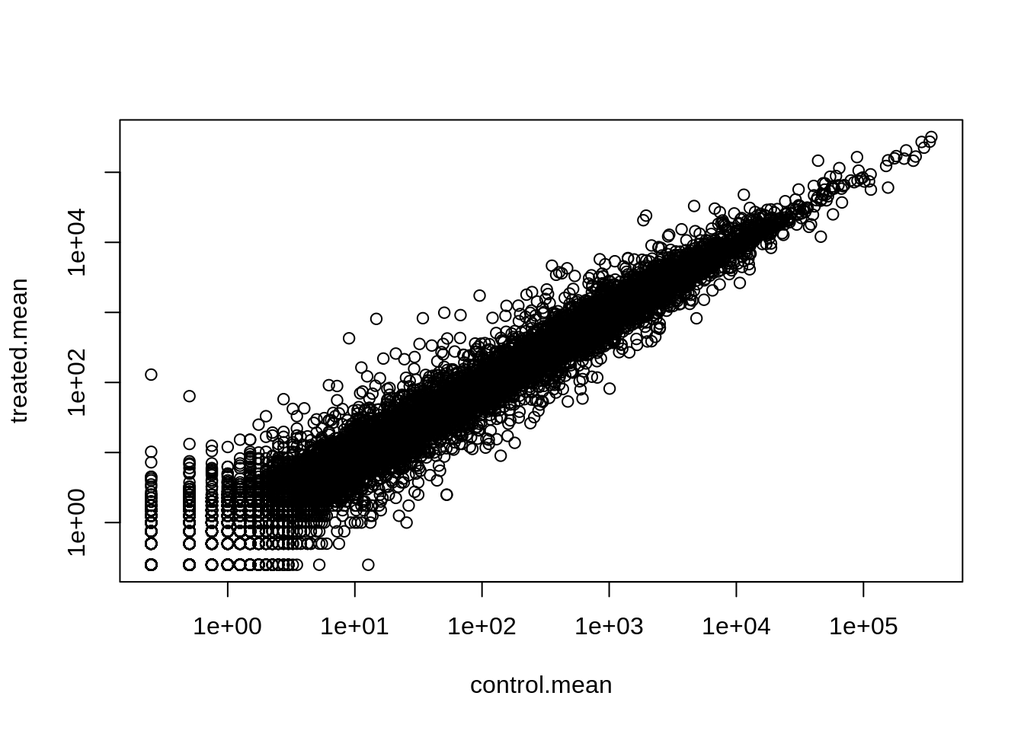

```r
plot(meancounts, log="xy")
```

We often use log2 in this field because it has nice math properties that make interpretation more straightforward.

```r
log2(40/10)
```

```
## [1] 2
```

```r
log2(10/10)
```

```
## [1] 0
```

```r
log2(5/10)
```

```
## [1] -1
```

We see 0 values for no change, positive values for increases and negative values for decreases. This nice property leads us to work with **log2(fold-change)** in genomics and proteomics.

Let’s add **log2(fold-change)** values to `meancounts`

```r
meancounts$log2fc <- log2(meancounts[,"treated.mean"]/meancounts[,"control.mean"])
head(meancounts)
```

```
##                 control.mean treated.mean      log2fc
## ENSG00000000003       900.75       658.00 -0.45303916
## ENSG00000000005         0.00         0.00         NaN
## ENSG00000000419       520.50       546.00  0.06900279
## ENSG00000000457       339.75       316.50 -0.10226805
## ENSG00000000460        97.25        78.75 -0.30441833
## ENSG00000000938         0.75         0.00        -Inf
```

The NaN result happens when you divide by zero and try to take the log. The -Inf result is given when you try to take the log of zero.

We need to exclude the genes with zero counts because we can’t say anything about them.

```r
meancounts[,1:2] == 0
```

[output not shown]

[output cut: 38640 more lines]

[output not shown]

```r
zero.vals <- which(meancounts[,1:2]==0, arr.ind=TRUE)
```

```r
head(zero.vals)
```

```
##                 row col
## ENSG00000000005   2   1
## ENSG00000004848  65   1
## ENSG00000004948  70   1
## ENSG00000005001  73   1
## ENSG00000006059 121   1
## ENSG00000006071 123   1
```

```r
to.rm <- unique(zero.vals[,"row"])
```

```r
mycounts <- meancounts[-to.rm,]
head(sort(to.rm))
```

```
## [1]  2  6 65 70 73 81
```

```r
head(mycounts)
```

```
##                 control.mean treated.mean      log2fc
## ENSG00000000003       900.75       658.00 -0.45303916
## ENSG00000000419       520.50       546.00  0.06900279
## ENSG00000000457       339.75       316.50 -0.10226805
## ENSG00000000460        97.25        78.75 -0.30441833
## ENSG00000000971      5219.00      6687.50  0.35769358
## ENSG00000001036      2327.00      1785.75 -0.38194109
```

```r
# How many genes are left?
nrow(mycounts)
```

```
## [1] 21817
```

> Q7. What is the purpose of the arr.ind argument in the which() function call above? Why would we then take the first column of the output and need to call the unique() function?

`array.inds` tells you which values are returned when the variable equals an specific array, in this case which values are TRUE. `unique` makes sure we don’t count any values twice.

> Q8.Using the up.ind vector above can you determine how many up regulated genes we have at the greater than 2 fc level?

```r
up.ind <- mycounts$log2fc > 2
which(up.ind, arr.ind = TRUE)
```

```
##   [1]    59   149   203   290   338   344   576  1048  1055  1196  1618  1680
##  [13]  1781  1939  1981  2038  2050  2118  2355  2358  2443  2514  2528  2599
##  [25]  2686  3186  3265  3459  3548  3788  3836  4052  4128  4129  4244  4453
##  [37]  4567  4659  4899  5124  5180  5181  5290  5386  5423  5484  5496  5498
##  [49]  5584  5725  5964  6055  6167  6246  6277  6288  6364  6453  6518  6553
##  [61]  6636  6869  6959  7034  7107  7108  7115  7183  7306  7348  7369  7422
##  [73]  7617  7790  7913  7970  7989  8330  8365  8396  8530  8706  8714  8723
##  [85]  8729  8741  8934  9175  9176  9213  9215  9270  9297  9392  9608  9753
##  [97]  9828  9924  9940  9968  9971 10079 10146 10174 10229 10234 10515 10577
## [109] 10631 10790 10955 10981 11019 11143 11177 11215 11341 11497 11520 11650
## [121] 11798 11899 12087 12153 12237 12254 12269 12365 12637 12742 12828 12894
## [133] 12922 12952 13071 13363 13426 13604 13813 13822 13832 13833 13851 13938
## [145] 14099 14140 14151 14419 14472 14493 14519 14700 14820 14908 15111 15511
## [157] 15526 15564 15567 15675 15766 15807 16310 16341 16361 16365 16415 16416
## [169] 16421 16494 16630 16631 16638 16725 16929 16996 17115 17132 17206 17211
## [181] 17285 17318 17332 17338 17357 17385 17485 17530 17550 17779 17918 17996
## [193] 18061 18120 18163 18186 18246 18456 18493 18576 18650 18744 18839 18914
## [205] 18960 19045 19052 19078 19129 19139 19150 19296 19297 19462 19530 19550
## [217] 19666 19803 19915 20073 20183 20214 20314 20374 20384 20432 20445 20465
## [229] 20553 20668 20766 20771 20774 20984 21093 21113 21119 21189 21190 21216
## [241] 21266 21283 21317 21321 21391 21403 21409 21454 21544 21603
```

250 genes

> Q9. Using the down.ind vector above can you determine how many down regulated genes we have at the greater than 2 fc level?

```r
down.ind <- mycounts$log2fc < (-2)
which(down.ind, arr.ind = TRUE)
```

```
##   [1]   341   365   418   443   451   623   624   662   684   825   925  1124
##  [13]  1142  1234  1238  1315  1351  1518  1551  1576  1623  1887  1911  1928
##  [25]  1965  1974  2131  2245  2342  2375  2670  3015  3020  3091  3279  3320
##  [37]  3332  3334  3355  3419  3794  3899  4001  4108  4286  4288  4331  4348
##  [49]  4504  4605  4906  4933  4984  5009  5015  5053  5067  5154  5282  5320
##  [61]  5397  5501  5518  5525  5535  5550  5555  5608  5684  5689  5724  5749
##  [73]  5756  5779  5811  5873  5890  5904  5950  6073  6116  6293  6310  6370
##  [85]  6504  6533  6684  6766  7000  7150  7189  7332  7396  7438  7521  7609
##  [97]  7627  7858  7869  7936  8003  8013  8049  8052  8081  8114  8210  8212
## [109]  8237  8407  8492  8501  8653  8667  8762  8875  9043  9189  9199  9274
## [121]  9457  9600  9628  9807  9843  9853  9859  9983  9998 10020 10040 10176
## [133] 10272 10361 10371 10487 10495 10526 10569 10586 10779 11138 11147 11159
## [145] 11204 11237 11243 11332 11345 11417 11424 11436 11642 11710 11769 11848
## [157] 12032 12240 12290 12395 12456 12466 12520 12549 12566 12618 12640 12671
## [169] 12678 12687 12741 12826 12915 12964 13027 13193 13197 13211 13230 13324
```

[output cut: 16 more lines]

367 genes

> Q10. Do you trust these results? Why or why not?

Not really because fold change could be large without being significant. We need to normalize our data first before we can see any real trends.

# DESeq2 analysis

```r
library(DESeq2)
```

```r
citation("DESeq2")
```

```
##
##   Love, M.I., Huber, W., Anders, S. Moderated estimation of fold change
##   and dispersion for RNA-seq data with DESeq2 Genome Biology 15(12):550
##   (2014)
##
## A BibTeX entry for LaTeX users is
##
##   @Article{,
##     title = {Moderated estimation of fold change and dispersion for RNA-seq data with DESeq2},
##     author = {Michael I. Love and Wolfgang Huber and Simon Anders},
##     year = {2014},
##     journal = {Genome Biology},
##     doi = {10.1186/s13059-014-0550-8},
##     volume = {15},
##     issue = {12},
##     pages = {550},
##   }
```

```r
dds <- DESeqDataSetFromMatrix(countData=counts,
                              colData=metadata,
                              design=~dex)
dds
```

```
## class: DESeqDataSet
## dim: 38694 8
## metadata(1): version
## assays(1): counts
## rownames(38694): ENSG00000000003 ENSG00000000005 ... ENSG00000283120
##   ENSG00000283123
## rowData names(0):
## colnames(8): SRR1039508 SRR1039509 ... SRR1039520 SRR1039521
## colData names(4): id dex celltype geo_id
```

Getting results:

```r
dds <- DESeq(dds)
res <- results(dds)
res
```

```
## log2 fold change (MLE): dex treated vs control
## Wald test p-value: dex treated vs control
## DataFrame with 38694 rows and 6 columns
##                  baseMean log2FoldChange     lfcSE      stat    pvalue
##                 <numeric>      <numeric> <numeric> <numeric> <numeric>
## ENSG00000000003  747.1942     -0.3507030  0.168246 -2.084470 0.0371175
## ENSG00000000005    0.0000             NA        NA        NA        NA
## ENSG00000000419  520.1342      0.2061078  0.101059  2.039475 0.0414026
## ENSG00000000457  322.6648      0.0245269  0.145145  0.168982 0.8658106
## ENSG00000000460   87.6826     -0.1471420  0.257007 -0.572521 0.5669691
## ...                   ...            ...       ...       ...       ...
## ENSG00000283115  0.000000             NA        NA        NA        NA
## ENSG00000283116  0.000000             NA        NA        NA        NA
## ENSG00000283119  0.000000             NA        NA        NA        NA
## ENSG00000283120  0.974916      -0.668258   1.69456 -0.394354  0.693319
## ENSG00000283123  0.000000             NA        NA        NA        NA
##                      padj
##                 <numeric>
## ENSG00000000003  0.163035
## ENSG00000000005        NA
## ENSG00000000419  0.176032
## ENSG00000000457  0.961694
## ENSG00000000460  0.815849
## ...                   ...
## ENSG00000283115        NA
## ENSG00000283116        NA
## ENSG00000283119        NA
## ENSG00000283120        NA
## ENSG00000283123        NA
```

Summarize results

```r
summary(res)
```

```
##
## out of 25258 with nonzero total read count
## adjusted p-value < 0.1
## LFC > 0 (up)       : 1563, 6.2%
## LFC < 0 (down)     : 1188, 4.7%
## outliers [1]       : 142, 0.56%
## low counts [2]     : 9971, 39%
## (mean count < 10)
## [1] see 'cooksCutoff' argument of ?results
## [2] see 'independentFiltering' argument of ?results
```

Customize results table

```r
res05 <- results(dds, alpha=0.05)
summary(res05)
```

```
##
## out of 25258 with nonzero total read count
## adjusted p-value < 0.05
## LFC > 0 (up)       : 1236, 4.9%
## LFC < 0 (down)     : 933, 3.7%
## outliers [1]       : 142, 0.56%
## low counts [2]     : 9033, 36%
## (mean count < 6)
## [1] see 'cooksCutoff' argument of ?results
## [2] see 'independentFiltering' argument of ?results
```

# Data Visualization

Volcano plots

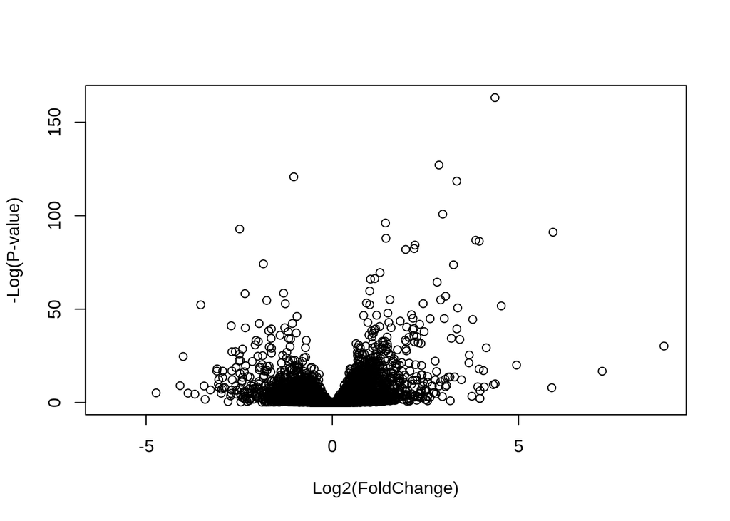

```r
plot( res$log2FoldChange,  -log(res$padj),
      xlab="Log2(FoldChange)",
      ylab="-Log(P-value)")
```

Make the plots more useful

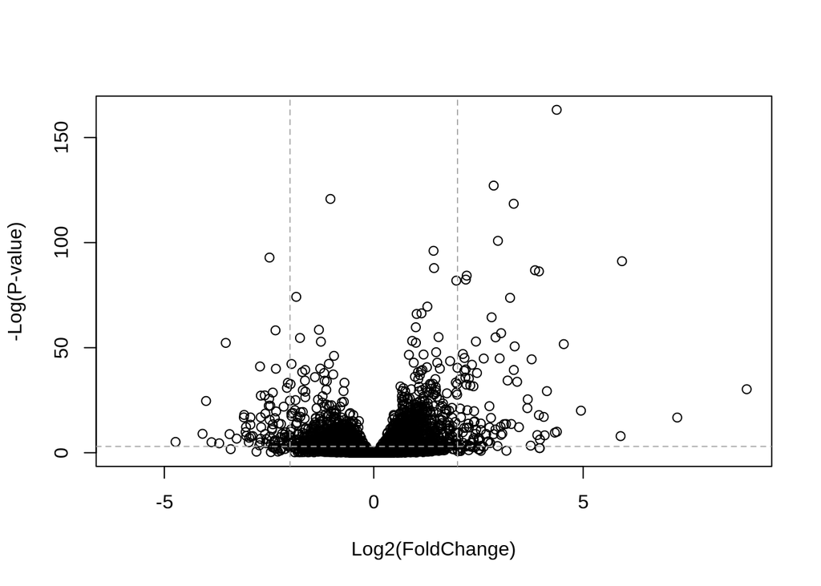

```r
plot( res$log2FoldChange,  -log(res$padj),
 ylab="-Log(P-value)", xlab="Log2(FoldChange)")

# Add some cut-off lines
abline(v=c(-2,2), col="darkgray", lty=2)
abline(h=-log(0.05), col="darkgray", lty=2)
```

Set up custom color vector

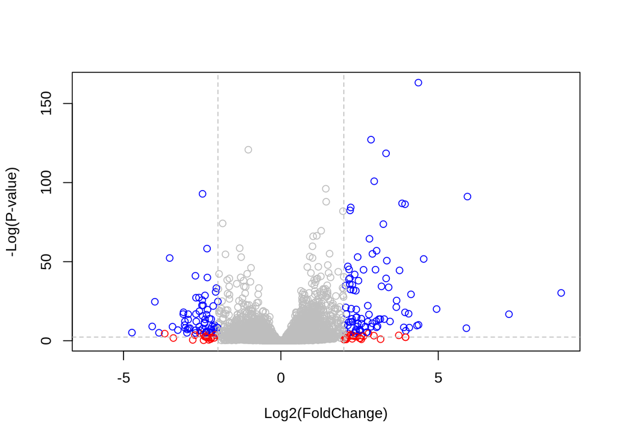

```r
# Setup our custom point color vector
mycols <- rep("gray", nrow(res))
mycols[ abs(res$log2FoldChange) > 2 ]  <- "red"

inds <- (res$padj < 0.01) & (abs(res$log2FoldChange) > 2 )
mycols[ inds ] <- "blue"

# Volcano plot with custom colors
plot( res$log2FoldChange,  -log(res$padj),
 col=mycols, ylab="-Log(P-value)", xlab="Log2(FoldChange)" )

# Cut-off lines
abline(v=c(-2,2), col="gray", lty=2)
abline(h=-log(0.1), col="gray", lty=2)
```